# Final Project

Rohit Yadav

10/12/2021

### **Project**

**Necessary codes**

**Analyzing multiple independent & one dependent variable.**  
**1st Visualization**  
In below plot we can see that number of observations are approximately equal of people having or not having heart disease, and there also not much variance in cholesterol and resting blood pressure, but we can see that people having chest pain type “ASY” are more likely to have heart disease, and in most of the cases people with heart disease “ATA” don’t have heart disease. Also in some cases people with chest pain type “ASY” have high cholesterol and also high blood pressure.

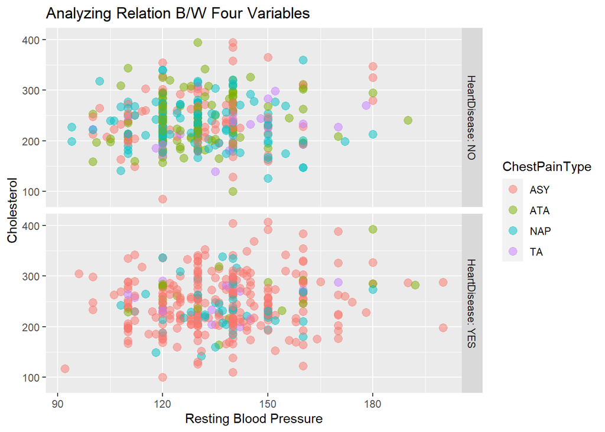

**2nd Visualization**  
In the below visualization we can see that there is not much variance in Old Peak and Resting ECG but we can see that people having ST Slope “flat” are more likely to have heart disease whereas in most of the case people having ST Slope “UP” don’t have heart disease, we can also point out that we have Resting ECG “Normal” in most of the cases.

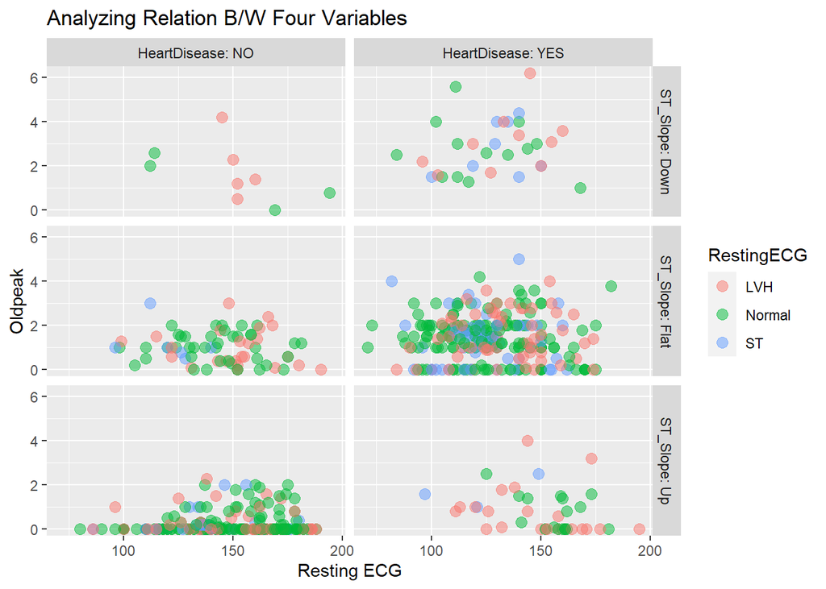

**Analyzing the data with a interactive plot**  
We can see in the below plot that People with high oldpeak are more likely to have heart disease and fall under all three reting ecg category.

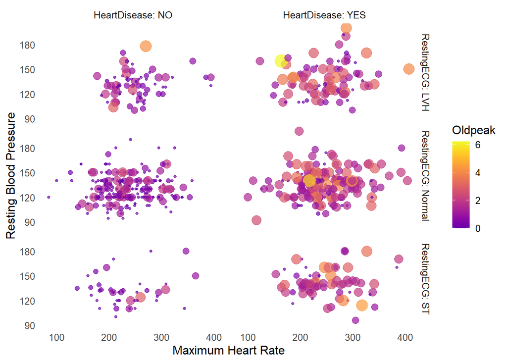

Now in the below plot we can clearly see that people who don’t have Fasting blood suger also have a high old peak are more likely to have heart disease.

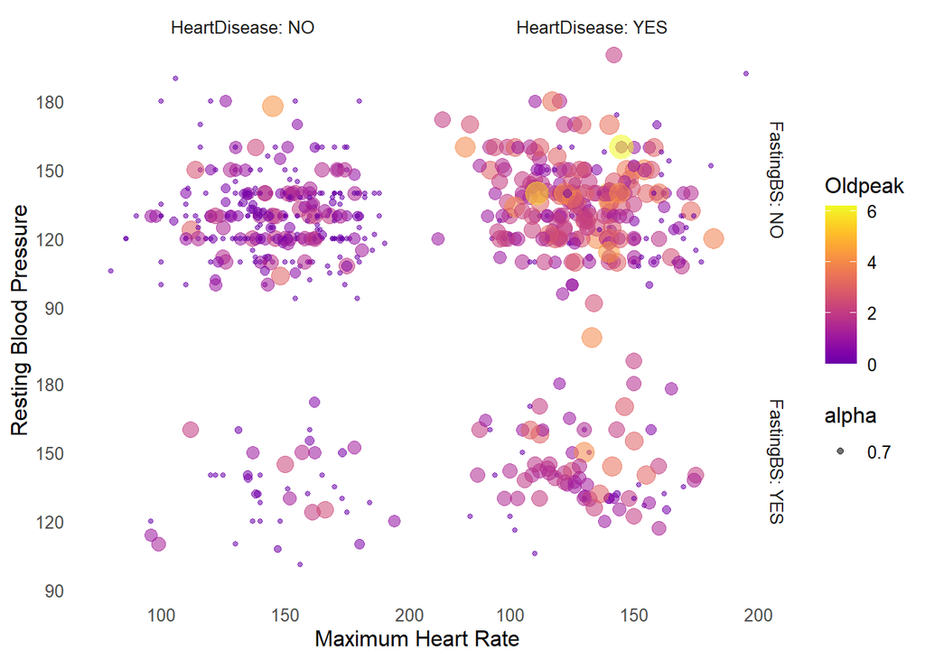